# CAD Introduction

Modified

Th 2023-03-09 11:42

## 2D Modeling

This tutorial was originally written by Drei, and it was rewritten and illustrated by vocx. This tutorial is meant to introduce the reader to the basic workflow of the

[figure not shown]

`Sketcher` Workbench by modeling the drawing shown in Figure 1.

Figure 1: Sketch

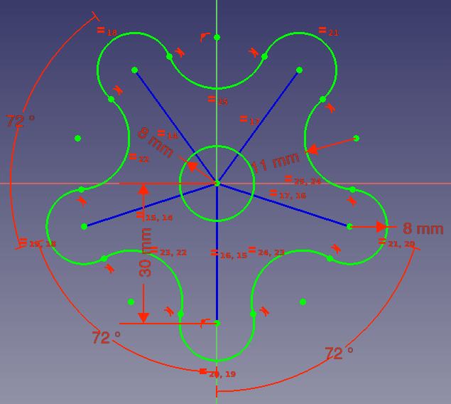

The [Sketcher Workbench](https://wiki.freecad.org/Sketcher_Workbench) exists as a standalone module, so it can be used to draw generic 2D (planar) objects. However, it is mostly used in conjunction with the

[figure not shown]

`Part Design` Workbench. A closed sketch is normally used to create a face or a profile to be extruded into a solid body with an operation such as

[figure not shown]

`Pad` found in the

[figure not shown]

`Part Design` Workbench.

The tutorial may be found [here](https://wiki.freecad.org/Basic_Sketcher_Tutorial).

## 3D Modeling

In this tutorial, you will be using the

[figure not shown]

`Part Design` Workbench to create a 3D solid model of the part shown in Figure 2.

Figure 2: Part Drawing

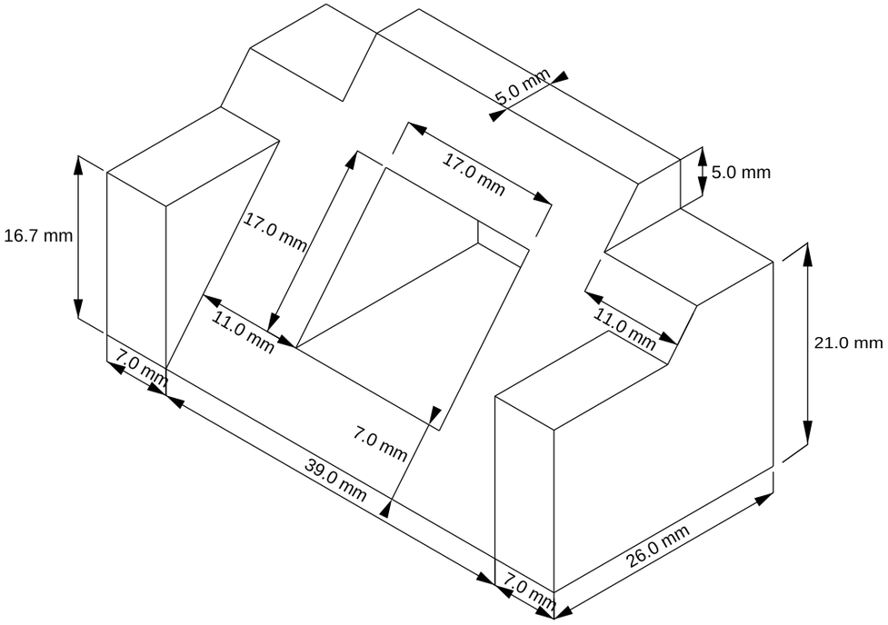

All of the necessary dimensions to complete this task are given. You will start by creating a core shape from a base Sketch and then build on that shape, adding what is known as Features. These features will either add material to, or remove material from the solid by use of additional sketches and accompanying feature operations. This Tutorial will not use every feature and tool available within the Part Design Workbench, but should use enough to give the user of this tutorial a basic foundation upon which to build their knowledge and skills.

The tutorial may be found [here](https://wiki.freecad.org/Basic_Part_Design_Tutorial).